# EDA

```python
import numpy as np
import pandas as pd
import pandas_profiling
import matplotlib.pyplot as plt
import seaborn as sns
sns.set()
```

```python
''' load and view the data '''
data = pd.read_csv("../csv/suicide.csv", index_col = 0)
data
```

|  | country | year | sex | age | suicides_no | population | gdp_for_year | gdp_per_capita | generation | continent |
| --- | --- | --- | --- | --- | --- | --- | --- | --- | --- | --- |
| 1 | Albania | 1987 | Male | 15-24 | 21 | 312900.0 | 2.156625e+09 | 796 | Generation X | Europe |
| 2 | Albania | 1987 | Male | 35-54 | 16 | 308000.0 | 2.156625e+09 | 796 | Silent | Europe |
| 3 | Albania | 1987 | Female | 15-24 | 14 | 289700.0 | 2.156625e+09 | 796 | Generation X | Europe |
| 4 | Albania | 1987 | Male | 75+ | 1 | 21800.0 | 2.156625e+09 | 796 | G.I. Generation | Europe |
| 5 | Albania | 1987 | Male | 25-34 | 9 | 274300.0 | 2.156625e+09 | 796 | Boomers | Europe |
| ... | ... | ... | ... | ... | ... | ... | ... | ... | ... | ... |
| 27656 | Uzbekistan | 2014 | Female | 35-54 | 107 | 3620833.0 | 6.306708e+10 | 2309 | Generation X | Asia |
| 27657 | Uzbekistan | 2014 | Female | 75+ | 9 | 348465.0 | 6.306708e+10 | 2309 | Silent | Asia |
| 27658 | Uzbekistan | 2014 | Male | 5-14 | 60 | 2762158.0 | 6.306708e+10 | 2309 | Generation Z | Asia |
| 27659 | Uzbekistan | 2014 | Female | 5-14 | 44 | 2631600.0 | 6.306708e+10 | 2309 | Generation Z | Asia |
| 27660 | Uzbekistan | 2014 | Female | 55-74 | 21 | 1438935.0 | 6.306708e+10 | 2309 | Boomers | Asia |

27660 rows × 10 columns

```python
profile = pandas_profiling.ProfileReport(data, title="Pandas Profiling Report")
profile.to_file("pandas_profiling.html")
'''
pandas profiling gives a great first look summary of the data - included
we can see:
    - variable types: categorical 5, numerical 6 (including the index column)
    - number of variables: 11 (including the index column)
    - missing values: 0%
    - duplicate rows: 0%
    - the distributions of each variable
    - samples and extreme values of each variable
    - different types of correlations of variables
and so on.
'''
```

```
'\npandas profiling gives a great first look summary of the data - included\nwe can see:\n    - variable types: categorical 5, numerical 6 (including the index column)\n    - number of variables: 11 (including the index column)\n    - missing values: 0%\n    - duplicate rows: 0%\n    - the distribut…
```

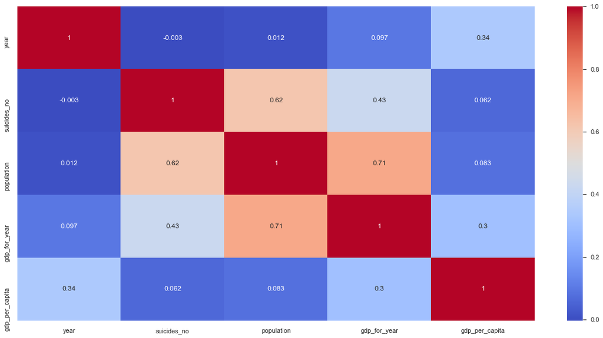

```python
''' Although it can be seen in the pandas profiling, we put the correlation here too.'''
sns.set()
plt.figure(figsize=(20,10))
sns.heatmap(data.corr(), annot=True, fmt='.2g', cmap= 'coolwarm')
# theres a high correlation to suicides_no with population which makes sense
# Gdps make sense
# One would expect a higher correlation with gpd_for_year and gpd_per_capita
# But it could make sense to see suicides_no dropping as gpd increases. - more gpd => more money => more happy people
```

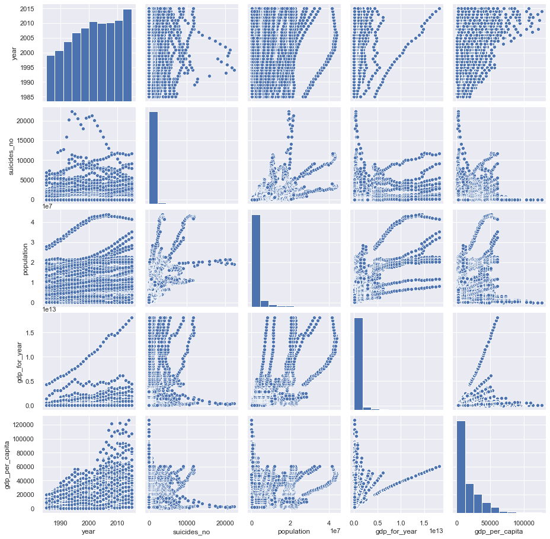

```python
''' look at the pairplot of all numerical variables '''
sns.pairplot(data)
```

# From the pairplot we can see a few peculiar/interesting things:

1. I would hope that the suicide rate decreases each year but it looks like it does not. We can see that the level of suicide numbers of groups (year, country, age, sex group) increase, although the peak was somewhere around 1994.
2. One would expect all populations to stricly increase as years increase since the measuring interval of the population is a WHOLE year but the one group with the most people have a peak and then decrease for a few years.
3. As expected, both GDPs increase each year.
4. The suicide_no x population pairplot does keep the trend of more people means more suicides (as could be seen in the pandas profiling, since these variables are positively correlated), however the peak in the middle is kind of unexpected? It probably is the same group that has the highest suicide number.
5. The GPD per capita after reaching a certain threshold drop the number of suicides a lot (pairplot[1, 4]). There are a few countries that look like they would continue to increase.

```python
'''As curious data scientists, we would like to know the answers to the few questions we have seen in the pairplot.'''

# Q: What country has the highest suicide numbers?

data.sort_values("suicides_no").tail(20)

# The top 20 groups with the highest suicide numbers are all groups from the Russian Federation, all male and all in the age of 35-54
# (in different years though). This also answers what country is the one whose population is not as high but still has the highest suicide number.
# We have to note that here, we're are talking about absolute numbers.
```

|  | country | year | sex | age | suicides_no | population | gdp_for_year | gdp_per_capita | generation | continent |
| --- | --- | --- | --- | --- | --- | --- | --- | --- | --- | --- |
| 21027 | Russian Federation | 2008 | Male | 35-54 | 11848 | 20041975.0 | 1.660844e+12 | 12359 | Boomers | Europe |
| 20798 | Russian Federation | 1989 | Male | 35-54 | 12030 | 18058500.0 | 5.065002e+11 | 3740 | Silent | Europe |
| 20810 | Russian Federation | 1990 | Male | 35-54 | 12517 | 18495100.0 | 5.168143e+11 | 3789 | Silent | Europe |
| 20822 | Russian Federation | 1991 | Male | 35-54 | 12746 | 18782900.0 | 5.179630e+11 | 3773 | Boomers | Europe |
| 21015 | Russian Federation | 2007 | Male | 35-54 | 13065 | 20173873.0 | 1.299705e+12 | 9643 | Boomers | Europe |
| 21003 | Russian Federation | 2006 | Male | 35-54 | 14020 | 20336306.0 | 9.899305e+11 | 7313 | Boomers | Europe |
| 20834 | Russian Federation | 1992 | Male | 35-54 | 15824 | 18933500.0 | 4.602906e+11 | 3333 | Boomers | Europe |
| 20990 | Russian Federation | 2005 | Male | 35-54 | 15843 | 20550405.0 | 7.640171e+11 | 5611 | Boomers | Europe |
| 20978 | Russian Federation | 2004 | Male | 35-54 | 17465 | 20843896.0 | 5.910167e+11 | 4312 | Boomers | Europe |
| 20905 | Russian Federation | 1998 | Male | 35-54 | 18058 | 20487900.0 | 2.709531e+11 | 1948 | Boomers | Europe |
| 20966 | Russian Federation | 2003 | Male | 35-54 | 18681 | 21007346.0 | 4.303478e+11 | 3141 | Boomers | Europe |
| 20894 | Russian Federation | 1997 | Male | 35-54 | 18973 | 19913400.0 | 4.049265e+11 | 2907 | Boomers | Europe |
| 20953 | Russian Federation | 2002 | Male | 35-54 | 20119 | 21320535.0 | 3.451104e+11 | 2527 | Boomers | Europe |
| 20845 | Russian Federation | 1993 | Male | 35-54 | 20256 | 18908000.0 | 4.350837e+11 | 3160 | Boomers | Europe |
| 20881 | Russian Federation | 1996 | Male | 35-54 | 20562 | 19507100.0 | 3.917200e+11 | 2813 | Boomers | Europe |
| 20918 | Russian Federation | 1999 | Male | 35-54 | 20705 | 21016400.0 | 1.959058e+11 | 1412 | Boomers | Europe |
| 20929 | Russian Federation | 2000 | Male | 35-54 | 21063 | 21378098.0 | 2.597085e+11 | 1879 | Boomers | Europe |
| 20941 | Russian Federation | 2001 | Male | 35-54 | 21262 | 21476420.0 | 3.066027e+11 | 2229 | Boomers | Europe |
| 20869 | Russian Federation | 1995 | Male | 35-54 | 21706 | 19249600.0 | 3.955311e+11 | 2844 | Boomers | Europe |
| 20857 | Russian Federation | 1994 | Male | 35-54 | 22338 | 19044200.0 | 3.950773e+11 | 2853 | Boomers | Europe |

```python
# Q: What is the group whose population decreases?

# Since theyre the peak by a lot, get the groups with the highest population numbers and then sort them out by year to see if it holds true.
data.sort_values(["population"]).tail(40).sort_values(["year"])

# A: All the groups are from the US, of age 35-54, although two different generations. For these we can see how the population increases
# with the peak at around 2006-2007 for women and then decreases for some reason. The suicide rate doesn't seem to increase by a lot, though.
```

|  | country | year | sex | age | suicides_no | population | gdp_for_year | gdp_per_capita | generation | continent |
| --- | --- | --- | --- | --- | --- | --- | --- | --- | --- | --- |
| 26823 | United States | 1996 | Male | 35-54 | 8984 | 37405100.0 | 8.100201e+12 | 32928 | Boomers | Americas |
| 26826 | United States | 1996 | Female | 35-54 | 2594 | 38357900.0 | 8.100201e+12 | 32928 | Boomers | Americas |
| 26836 | United States | 1997 | Male | 35-54 | 8920 | 38339600.0 | 8.608515e+12 | 34644 | Boomers | Americas |
| 26838 | United States | 1997 | Female | 35-54 | 2758 | 39291000.0 | 8.608515e+12 | 34644 | Boomers | Americas |
| 26846 | United States | 1998 | Male | 35-54 | 9192 | 39000700.0 | 9.089168e+12 | 36164 | Boomers | Americas |
| 26850 | United States | 1998 | Female | 35-54 | 2776 | 40104100.0 | 9.089168e+12 | 36164 | Boomers | Americas |
| 26858 | United States | 1999 | Male | 35-54 | 8873 | 39753404.0 | 9.660624e+12 | 38072 | Boomers | Americas |
| 26862 | United States | 1999 | Female | 35-54 | 2674 | 40861603.0 | 9.660624e+12 | 38072 | Boomers | Americas |
| 26870 | United States | 2000 | Male | 35-54 | 9263 | 40945028.0 | 1.028478e+13 | 39218 | Boomers | Americas |
| 26874 | United States | 2000 | Female | 35-54 | 2736 | 41881451.0 | 1.028478e+13 | 39218 | Boomers | Americas |
| 26882 | United States | 2001 | Male | 35-54 | 9684 | 41638996.0 | 1.062182e+13 | 40018 | Boomers | Americas |
| 26886 | United States | 2001 | Female | 35-54 | 2893 | 42567863.0 | 1.062182e+13 | 40018 | Boomers | Americas |
| 26898 | United States | 2002 | Female | 35-54 | 3058 | 42957716.0 | 1.097751e+13 | 40845 | Boomers | Americas |
| 26894 | United States | 2002 | Male | 35-54 | 10101 | 42042827.0 | 1.097751e+13 | 40845 | Boomers | Americas |
| 26910 | United States | 2003 | Female | 35-54 | 3058 | 42997878.0 | 1.151067e+13 | 42468 | Boomers | Americas |
| 26906 | United States | 2003 | Male | 35-54 | 10025 | 42177315.0 | 1.151067e+13 | 42468 | Boomers | Americas |
| 26922 | United States | 2004 | Female | 35-54 | 3399 | 43240905.0 | 1.227493e+13 | 44867 | Boomers | Americas |
| 26918 | United States | 2004 | Male | 35-54 | 10145 | 42486552.0 | 1.227493e+13 | 44867 | Boomers | Americas |
| 26934 | United States | 2005 | Female | 35-54 | 3209 | 43509335.0 | 1.309373e+13 | 47423 | Boomers | Americas |
| 26930 | United States | 2005 | Male | 35-54 | 10332 | 42835394.0 | 1.309373e+13 | 47423 | Boomers | Americas |
| 26942 | United States | 2006 | Male | 35-54 | 10641 | 43139910.0 | 1.385589e+13 | 49666 | Boomers | Americas |
| 26946 | United States | 2006 | Female | 35-54 | 3376 | 43805214.0 | 1.385589e+13 | 49666 | Boomers | Americas |
| 26958 | United States | 2007 | Female | 35-54 | 3525 | 43607902.0 | 1.447764e+13 | 51585 | Boomers | Americas |
| 26954 | United States | 2007 | Male | 35-54 | 10978 | 42992076.0 | 1.447764e+13 | 51585 | Boomers | Americas |
| 26966 | United States | 2008 | Male | 35-54 | 11371 | 43002471.0 | 1.471858e+13 | 52128 | Boomers | Americas |
| 26970 | United States | 2008 | Female | 35-54 | 3619 | 42893858.0 | 1.471858e+13 | 52128 | Boomers | Americas |
| 26978 | United States | 2009 | Male | 35-54 | 11613 | 42932194.0 | 1.441874e+13 | 50563 | Boomers | Americas |
| 26982 | United States | 2009 | Female | 35-54 | 3664 | 42836835.0 | 1.441874e+13 | 50563 | Boomers | Americas |
| 26994 | United States | 2010 | Female | 35-54 | 3604 | 42711237.0 | 1.496437e+13 | 51989 | Generation X | Americas |
| 26990 | United States | 2010 | Male | 35-54 | 11767 | 42798501.0 | 1.496437e+13 | 51989 | Generation X | Americas |
| 27002 | United States | 2011 | Male | 35-54 | 11681 | 42566273.0 | 1.551793e+13 | 53452 | Generation X | Americas |
| 27006 | United States | 2011 | Female | 35-54 | 3776 | 42485156.0 | 1.551793e+13 | 53452 | Generation X | Americas |
| 27014 | United States | 2012 | Male | 35-54 | 11763 | 42326226.0 | 1.615526e+13 | 55170 | Generation X | Americas |
| 27018 | United States | 2012 | Female | 35-54 | 3857 | 42238495.0 | 1.615526e+13 | 55170 | Generation X | Americas |
| 27027 | United States | 2013 | Male | 35-54 | 11396 | 42085688.0 | 1.669152e+13 | 56520 | Generation X | Americas |
| 27030 | United States | 2013 | Female | 35-54 | 3776 | 41983845.0 | 1.669152e+13 | 56520 | Generation X | Americas |
| 27039 | United States | 2014 | Male | 35-54 | 11455 | 41858354.0 | 1.742761e+13 | 58531 | Generation X | Americas |
| 27042 | United States | 2014 | Female | 35-54 | 4018 | 41742299.0 | 1.742761e+13 | 58531 | Generation X | Americas |
| 27051 | United States | 2015 | Male | 35-54 | 11634 | 41658010.0 | 1.812071e+13 | 60387 | Generation X | Americas |
| 27054 | United States | 2015 | Female | 35-54 | 4053 | 41531809.0 | 1.812071e+13 | 60387 | Generation X | Americas |

```python
# Q: What groups look cutted off in the gpd per capita x suicides_no graph?

data[data["gdp_per_capita"].between(60000,65000)].sort_values("suicides_no")

# The one growing is probably the US males 35-54 as their number of suicides is still very high.
# After that one can see the few countries with a pretty high gdp and 0 suicides.
```

|  | country | year | sex | age | suicides_no | population | gdp_for_year | gdp_per_capita | generation | continent |
| --- | --- | --- | --- | --- | --- | --- | --- | --- | --- | --- |
| 17244 | Netherlands | 2008 | Female | 5-14 | 0 | 972276.0 | 9.362282e+11 | 60375 | Generation Z | Europe |
| 7596 | Denmark | 2012 | Female | 5-14 | 0 | 324455.0 | 3.271489e+11 | 62071 | Generation Z | Europe |
| 11851 | Iceland | 2005 | Female | 15-24 | 0 | 21198.0 | 1.669149e+10 | 60712 | Millenials | Europe |
| 11852 | Iceland | 2005 | Female | 25-34 | 0 | 20904.0 | 1.669149e+10 | 60712 | Generation X | Europe |
| 11853 | Iceland | 2005 | Female | 5-14 | 0 | 21721.0 | 1.669149e+10 | 60712 | Millenials | Europe |
| ... | ... | ... | ... | ... | ... | ... | ... | ... | ... | ... |
| 27054 | United States | 2015 | Female | 35-54 | 4053 | 41531809.0 | 1.812071e+13 | 60387 | Generation X | Americas |
| 27053 | United States | 2015 | Male | 15-24 | 4359 | 22615073.0 | 1.812071e+13 | 60387 | Millenials | Americas |
| 27052 | United States | 2015 | Male | 25-34 | 5503 | 22137097.0 | 1.812071e+13 | 60387 | Millenials | Americas |
| 27050 | United States | 2015 | Male | 55-74 | 9068 | 32264697.0 | 1.812071e+13 | 60387 | Boomers | Americas |
| 27051 | United States | 2015 | Male | 35-54 | 11634 | 41658010.0 | 1.812071e+13 | 60387 | Generation X | Americas |

216 rows × 10 columns

# Visualization of suicide_no distributions dependant on different categorical variables

One cannot compare the absolute values of suicide numbers because of the fact that as stated above, the more people, the more absolute proportion of the people can commit suicide. Therefore we have to normalize the suicides first. We normalize them and show the numbers per 100k people of the given group we create.

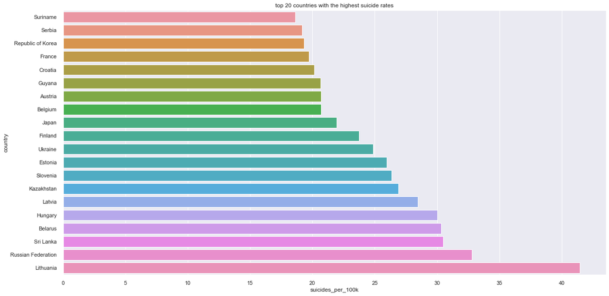

```python
'''top 20 Countries in suicides'''
countries = data.groupby("country").sum().reset_index()
countries["suicides_per_100k"] = (countries["suicides_no"] / countries["population"]) * 100000
plt.figure(figsize=(20,10))
plt.title("top 20 countries with the highest suicide rates")
sns.barplot(x="suicides_per_100k", y="country", data=countries.sort_values("suicides_per_100k").tail(20))
```

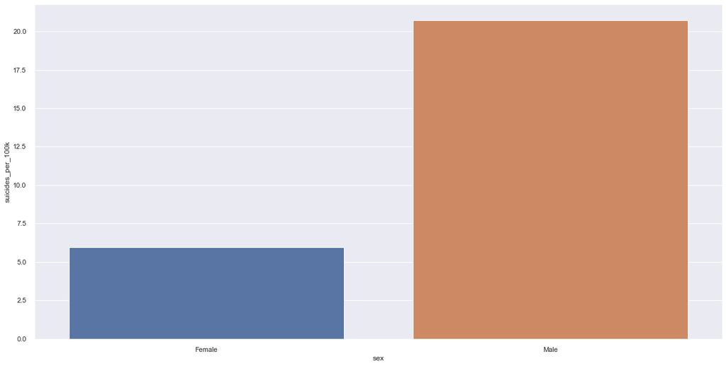

```python
'''Males vs Females in suicides'''
sex = data.groupby("sex").sum().reset_index()
sex["suicides_per_100k"] = (sex["suicides_no"] / sex["population"]) * 100000
plt.figure(figsize=(20,10))
sns.barplot(x="sex", y="suicides_per_100k", data=sex)
# It has been widely known that men commit suicides more than women, which we can also see in our dataset.
```

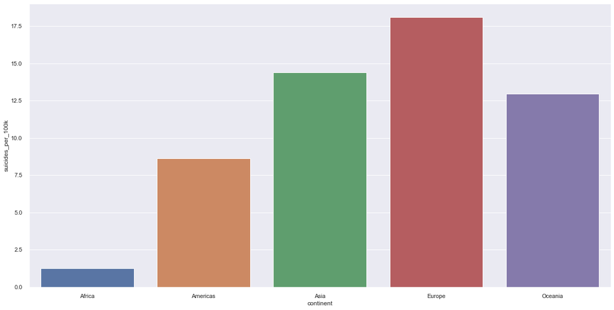

```python
''' Continents x Suicides '''
cont = data.groupby("continent").sum().reset_index()
cont["suicides_per_100k"] = (cont["suicides_no"] / cont["population"]) * 100000
plt.figure(figsize=(20,10))
sns.barplot(x="continent", y="suicides_per_100k", data=cont)
# Europe has the highest suicides across all continents, which could be because of the Russian Federation being European - huge absolute suicide numbers
# while the population is not as low to influence the whole continent.
```

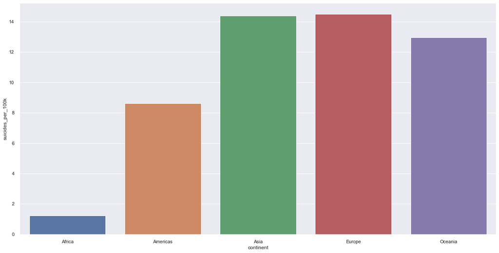

```python
''' Checking whether Europes suicides per 100k is really the highest because of the Russian federation'''
no_russia = data[data["country"] != "Russian Federation"]
cont = no_russia.groupby("continent").sum().reset_index()
cont["suicides_per_100k"] = (cont["suicides_no"] / cont["population"]) * 100000
plt.figure(figsize=(20,10))
sns.barplot(x="continent", y="suicides_per_100k", data=cont)
# removing The Russian Federation from the dataset pretty much equals out Europe and Asia. That is however still not to be expected. From my own bubble of social media,
# I hear that Asian people commit suicides lots. Therefore I expected Asia to be way above Europe.
```

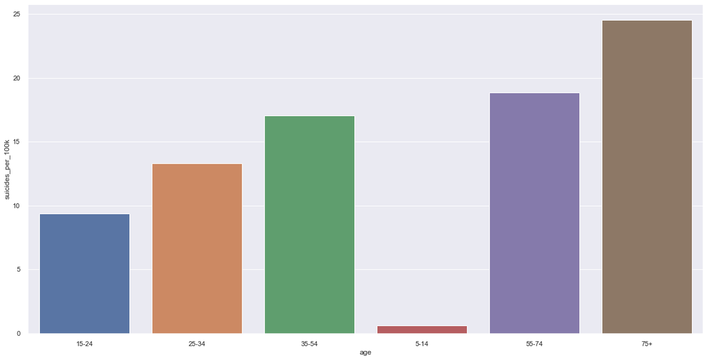

```python
''' Different age groups with their suicide numbers '''
age = data.groupby("age").sum().reset_index()
age["suicides_per_100k"] = (age["suicides_no"] / age["population"]) * 100000
plt.figure(figsize=(20,10))
sns.barplot(x="age", y="suicides_per_100k", data=age)
# The eldest people commit the most suicides.
```

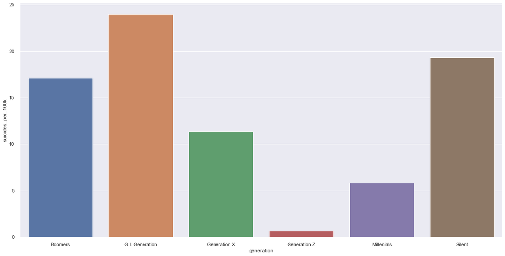

```python
''' Generations x suicides '''
gen = data.groupby("generation").sum().reset_index()
gen["suicides_per_100k"] = (gen["suicides_no"] / gen["population"]) * 100000
plt.figure(figsize=(20,10))
sns.barplot(x="generation", y="suicides_per_100k", data=gen)
# The eldest generations commit suicides the most which is sort of what we expected from the graph above.
```

# Clustering

We try clustering suicides number with the gdp per capita as that could find out the suicide rate per gdp per capita group

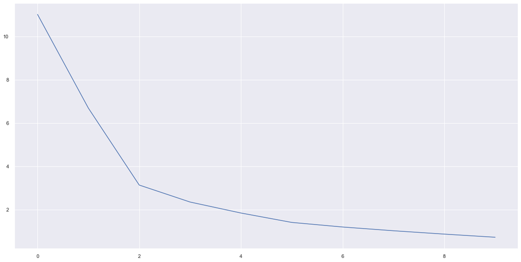

```python
from sklearn.cluster import KMeans
from sklearn.preprocessing import MinMaxScaler


'''After scaling the data, we find the optimal number of clusters with the elbow method.'''
data["suicides_per_100k"] = (data["suicides_no"] / data["population"]) * 100000
country = data.groupby("country").mean().reset_index()
gdp_sui = country[["gdp_per_capita", "suicides_per_100k", "country"]]
scaler = MinMaxScaler()
transformed_gdp_sui = scaler.fit_transform(gdp_sui[["gdp_per_capita", "suicides_per_100k"]])

losses = []
for i in range(1, 11):
    kmeans = KMeans(n_clusters=i)
    kmeans.fit(transformed_gdp_sui)
    losses.append(kmeans.inertia_)
sns.set()
plt.figure(figsize=(20,10))
sns.lineplot(range(10), losses)
```

From the plot, we choose 4 clusters and visualize it

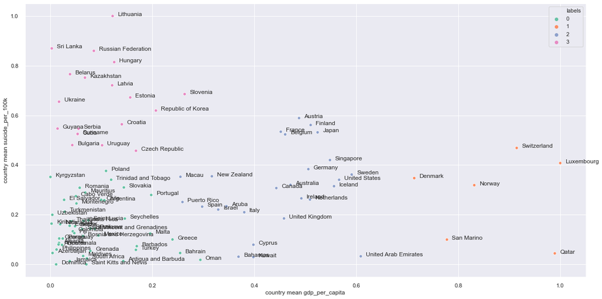

```python
kmeans = KMeans(n_clusters=4)
kmeans.fit(transformed_gdp_sui)

labels = kmeans.predict(transformed_gdp_sui)
df = pd.DataFrame(pd.concat([pd.DataFrame(transformed_gdp_sui, columns={"gdp_per_capita", "suicides_per_100k"}), pd.DataFrame(labels, columns={"labels"})], axis=1))
df["country"] = gdp_sui["country"]
plt.figure(figsize=(20,10))
sns.scatterplot(x="gdp_per_capita", y="suicides_per_100k", hue="labels", data=df, palette="Set2")
plt.xlabel("country mean gdp_per_capita")
plt.ylabel("country mean suicide_per_100k")

def label_point(x, y, val, ax):
    a = pd.concat({'x': x, 'y': y, 'val': val}, axis=1)
    for i, point in a.iterrows():
        ax.text(point['x']+0.01, point['y'], str(point['val']))

label_point(df["gdp_per_capita"], df["suicides_per_100k"], df["country"], plt.gca())
```

From this graph we cannot really find a relationship between country mean gdp per capita and country mean suicides rate. One would guess that the more gdp_per_capita the less suicides, but as we can see e.g. Switzerland or Luxembourg, that doesn't really seem like it.

# Variables throughout time

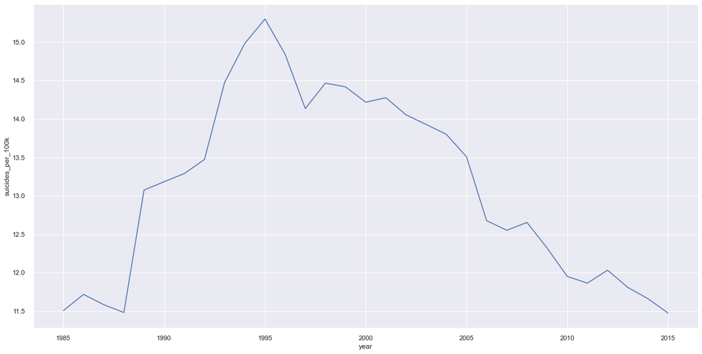

```python
''' Years x normalized suicide numbers'''
# We have seen a bit about this in the pairplot but unnormalized and ungrouped.

years = data.groupby("year").sum().reset_index()
years["suicides_per_100k"] = (years["suicides_no"] / years["population"]) * 100000
plt.figure(figsize=(20,10))
sns.lineplot(x="year", y="suicides_per_100k", data=years)
```

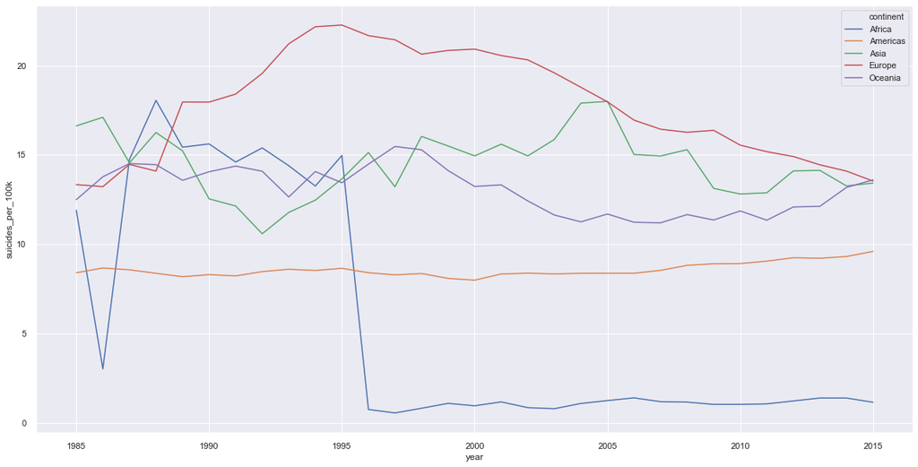

```python
''' How does each continent hold? '''
conts = data.groupby(["continent", "year"]).sum().reset_index()
conts["suicides_per_100k"] = (conts["suicides_no"] / conts["population"]) * 100000
plt.figure(figsize=(20,10))
sns.lineplot(data=conts, x="year", y="suicides_per_100k", hue="continent")
# The european peak is expected from what weve seen so far. Although it is nice that it is decreasing afterwards.
```

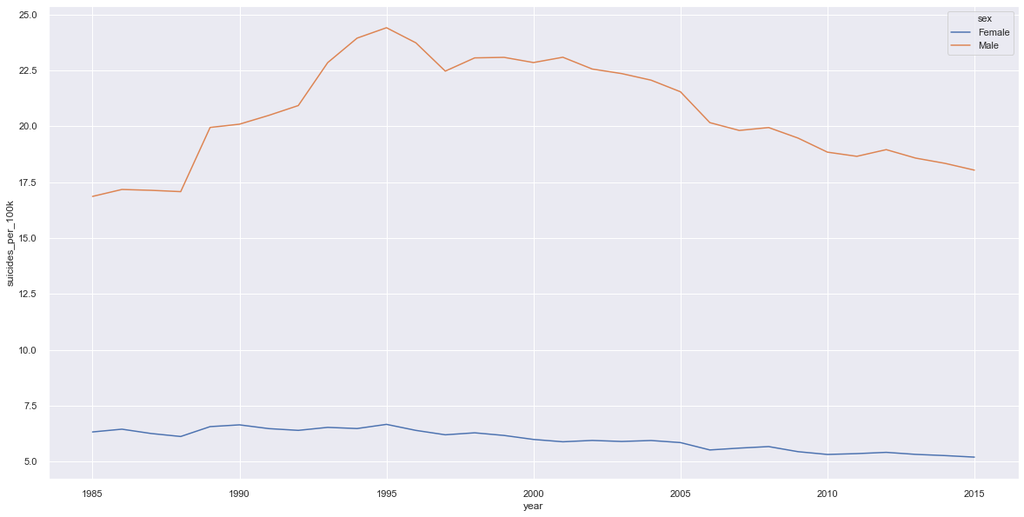

```python
''' Males/females suicides x year'''
sex = data.groupby(["sex", "year"]).sum().reset_index()
sex["suicides_per_100k"] = (sex["suicides_no"] / sex["population"]) * 100000
plt.figure(figsize=(20,10))
sns.lineplot(data=sex, x="year", y="suicides_per_100k", hue="sex")
```

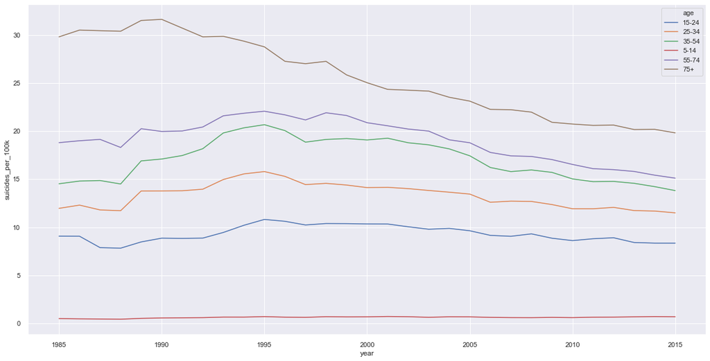

```python
''' Age x Year '''

age = data.groupby(["age", "year"]).sum().reset_index()
age["suicides_per_100k"] = (age["suicides_no"] / age["population"]) * 100000
plt.figure(figsize=(20,10))
sns.lineplot(data=age, x="year", y="suicides_per_100k", hue="age")
```

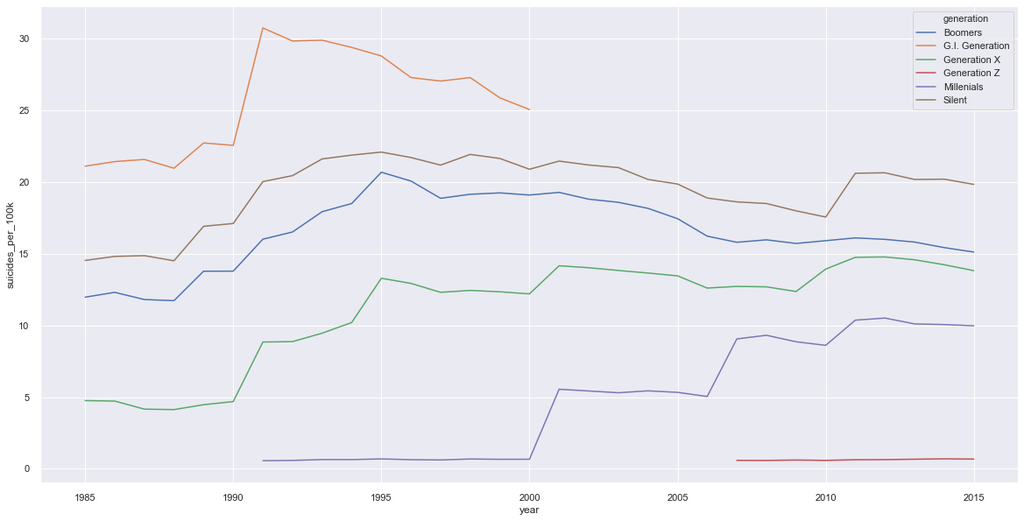

```python
''' Generation x Year '''

gen = data.groupby(["generation", "year"]).sum().reset_index()
gen["suicides_per_100k"] = (gen["suicides_no"] / gen["population"]) * 100000
plt.figure(figsize=(20,10))
sns.lineplot(data=gen, x="year", y="suicides_per_100k", hue="generation")
```

# Own interest

As was mentioned above, I have heard a lot of stuff about Asian countries commiting the most suicides, South Korea and Japan in particular. In the country comparison, both of these contries were included in the top 20, Japan ahead of South Korea. Here I take a brief look at these countries.

```python
korpan = data[data["country"].isin({"Republic of Korea", "Japan"})]
```

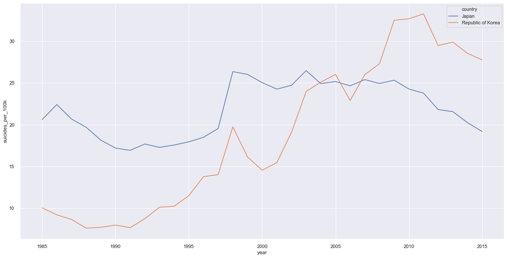

```python
'''timeline of koreans and japanese suicides'''
divd = korpan.groupby(["country", "year"]).sum().reset_index()
divd["suicides_per_100k"] = (divd["suicides_no"] / divd["population"]) * 100000
plt.figure(figsize=(20,10))
sns.lineplot(data=divd, x="year", y="suicides_per_100k", hue="country")
# south koreas suicide rate increased in only in the last few years which could be why it was behind japan in the top 20 countries.
```

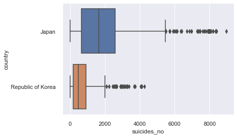

```python
sns.boxplot(x="suicides_no", y="country", data=korpan)
# just a quick look at the groups suicide numbers variance. Japan has a much larger variance.
```

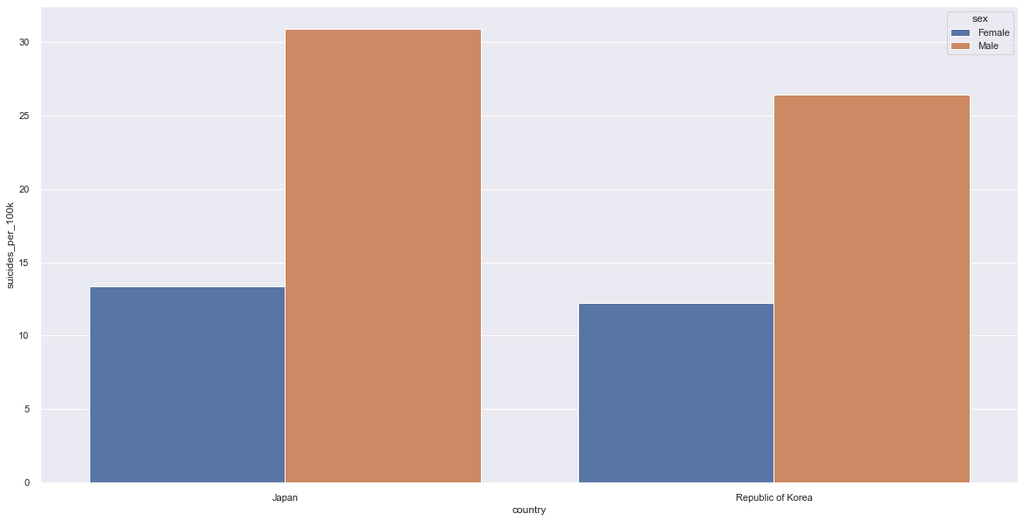

```python
'''Suicides rates per sex in Japan and Korea'''
divd = korpan.groupby(["country", "sex"]).sum().reset_index()
divd["suicides_per_100k"] = (divd["suicides_no"] / divd["population"]) * 100000
plt.figure(figsize=(20,10))
sns.barplot(data=divd, x="country", y="suicides_per_100k", hue="sex")
# both sexes commit more suicides in Japan
```

# Discussion

We now know how the dataset behaves. The Europeans have the highest suicide rates, although that might not be statistically significant as we have more European data than e.g. Asian data (although the normalized version proposes that Europeans do in fact commit more suicides). We found that the suicide number is positively correlated with gpd_for_year but not gpd_per_capita (without a p-value though). The Russian Federation has the highest absolute number of suicides, while Lithuania has the most suicides per 100k people. We have seen that throughout time, men commited more suicides each year. We found out that the eldest have the highest probability of commiting suicide, both by age/year and generation. This suggests to not use the generation variable as it can be calculated given a year and the age group. We then studied the Japan and South Korea suicide relationship.